# Chapter3. Pandas数据分析

### 3.2.3 Descriptive statistics 描述性统计

#### ① 常用统计方法

pandas提供了非常多的用于描述统计的方法，有些是聚合的，即返回降低一个维度的值，比如`sum()、mean()`等；有些返回相同size的对象，比如`cumsum()、cumprod()`等。这些方法中提供了对于axis参数的设置：

1. Series：不需要设置axis参数
2. DataFrame：index（axis=0, default）和columns（axis=1）

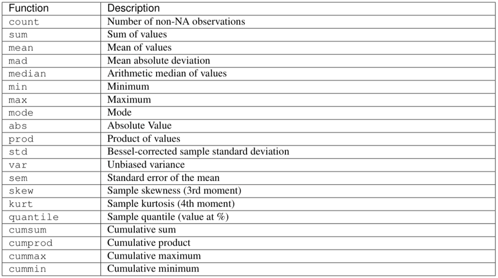

```python
df.mean()  #基于index求平均
```

```
A    0.236183
B   -0.364873
C    0.165561
dtype: float64
```

```python
df.mean(axis=1) #基于columns求平均
# df.mean(axis='columns')
```

```
2022-10-01    0.438560
2022-10-02   -0.128569
2022-10-03   -0.894344
2022-10-04    0.892768
2022-10-05    0.436666
2022-10-06   -0.260137
2022-10-07    0.047677
2022-10-08   -0.434297
Freq: D, dtype: float64
```

```python
df2 = df.copy()
df2.iloc[:3,0]=np.nan
df2
```

|  | A | B | C |
| --- | --- | --- | --- |
| 2022-10-01 | NaN | 0.962418 | 0.462161 |
| 2022-10-02 | NaN | -1.200499 | -0.112129 |
| 2022-10-03 | NaN | -1.726547 | -0.375088 |
| 2022-10-04 | 3.024233 | 0.360516 | -0.706446 |
| 2022-10-05 | -0.376288 | -0.155509 | 1.841796 |
| 2022-10-06 | 0.034091 | -0.552255 | -0.262247 |
| 2022-10-07 | 0.541646 | -0.603060 | 0.204446 |
| 2022-10-08 | -1.570842 | -0.004045 | 0.271995 |

```python
df2.mean(axis=1)  # Nan值在统计计算中会被自动排除，可以通过禁用skipna来实现不排除
```

```
2022-10-01    0.712289
2022-10-02   -0.656314
2022-10-03   -1.050817
2022-10-04    0.892768
2022-10-05    0.436666
2022-10-06   -0.260137
2022-10-07    0.047677
2022-10-08   -0.434297
Freq: D, dtype: float64
```

```python
df2.mean(axis=1,skipna=False)
```

```
2022-10-01         NaN
2022-10-02         NaN
2022-10-03         NaN
2022-10-04    0.892768
2022-10-05    0.436666
2022-10-06   -0.260137
2022-10-07    0.047677
2022-10-08   -0.434297
Freq: D, dtype: float64
```

```python
df2.cumsum()  # 累计求和
```

|  | A | B | C |
| --- | --- | --- | --- |
| 2022-10-01 | NaN | 0.962418 | 0.462161 |
| 2022-10-02 | NaN | -0.238081 | 0.350032 |
| 2022-10-03 | NaN | -1.964628 | -0.025056 |
| 2022-10-04 | 3.024233 | -1.604111 | -0.731502 |
| 2022-10-05 | 2.647945 | -1.759621 | 1.110294 |
| 2022-10-06 | 2.682036 | -2.311876 | 0.848047 |
| 2022-10-07 | 3.223682 | -2.914936 | 1.052492 |
| 2022-10-08 | 1.652840 | -2.918981 | 1.324488 |

#### ② 统计汇总

`describe()` 函数可以对pandas对象（Series或者DataFrame的一个维度）的数据进行统计汇总。

```python
s = pd.Series(np.random.randn(1000))    # 由随机数组成的Series对象
s.describe()
```

```
count    1000.000000
mean       -0.033978
std         1.028734
min        -3.432935
25%        -0.672320
50%        -0.025317
75%         0.582652
max         3.255073
dtype: float64
```

```python
s = pd.Series(['a','a','b','b','a','a',np.nan,'c','d','a'])  # 由字符串组成的Series对象
s.describe()
```

```
count     9
unique    4
top       a
freq      5
dtype: object
```

```python
df  # 由数值组成的DataFrame对象
```

|  | A | B | C |
| --- | --- | --- | --- |
| 2022-10-01 | -0.108899 | 0.962418 | 0.462161 |
| 2022-10-02 | 0.926922 | -1.200499 | -0.112129 |
| 2022-10-03 | -0.581398 | -1.726547 | -0.375088 |
| 2022-10-04 | 3.024233 | 0.360516 | -0.706446 |
| 2022-10-05 | -0.376288 | -0.155509 | 1.841796 |
| 2022-10-06 | 0.034091 | -0.552255 | -0.262247 |
| 2022-10-07 | 0.541646 | -0.603060 | 0.204446 |
| 2022-10-08 | -1.570842 | -0.004045 | 0.271995 |

```python
df.describe()
```

|  | A | B | C |
| --- | --- | --- | --- |
| count | 8.000000 | 8.000000 | 8.000000 |
| mean | 0.236183 | -0.364873 | 0.165561 |
| std | 1.352906 | 0.854082 | 0.776752 |
| min | -1.570842 | -1.726547 | -0.706446 |
| 25% | -0.427566 | -0.752420 | -0.290458 |
| 50% | -0.037404 | -0.353882 | 0.046159 |
| 75% | 0.637965 | 0.087095 | 0.319537 |
| max | 3.024233 | 0.962418 | 1.841796 |

```python
df2 = df.copy()
df2.iloc[:3,0]=['a','a','b']
df2  # 混合数据类型的DataFrame对象
```

|  | A | B | C |
| --- | --- | --- | --- |
| 2022-10-01 | a | 0.962418 | 0.462161 |
| 2022-10-02 | a | -1.200499 | -0.112129 |
| 2022-10-03 | b | -1.726547 | -0.375088 |
| 2022-10-04 | 3.024233 | 0.360516 | -0.706446 |
| 2022-10-05 | -0.376288 | -0.155509 | 1.841796 |
| 2022-10-06 | 0.034091 | -0.552255 | -0.262247 |
| 2022-10-07 | 0.541646 | -0.603060 | 0.204446 |
| 2022-10-08 | -1.570842 | -0.004045 | 0.271995 |

```python
df2.describe(include='all')
```

|  | A | B | C |
| --- | --- | --- | --- |
| count | 8 | 8.000000 | 8.000000 |
| unique | 7 | NaN | NaN |
| top | a | NaN | NaN |
| freq | 2 | NaN | NaN |
| mean | NaN | -0.364873 | 0.165561 |
| std | NaN | 0.854082 | 0.776752 |
| min | NaN | -1.726547 | -0.706446 |
| 25% | NaN | -0.752420 | -0.290458 |
| 50% | NaN | -0.353882 | 0.046159 |
| 75% | NaN | 0.087095 | 0.319537 |
| max | NaN | 0.962418 | 1.841796 |

#### ④ 计数

`value_counts()`可以对pandas对象的取值进行计数

```python
s = pd.Series(['a','a','b','b','a','a',np.nan,'c','d','a'])  # 由字符串组成的Series对象
s.value_counts()
```

```
a    5
b    2
c    1
d    1
dtype: int64
```

```python
s2 = pd.Series(np.random.randint(0,5,size=50))
s2.value_counts()
```

```
4    12
3    12
1    11
2     8
0     7
dtype: int64
```

```python
# mode()方法返回众数（出现次数最多的值，以Series对象返回）
s.mode()
```

```
0    a
dtype: object
```

```python
s2.mode()
```

```
0    3
1    4
dtype: int64
```

#### ③ 最大/最小值索引

`idxmin()、idxmax()`函数可以获取最小值和最大值的索引位置

```python
s = pd.Series(np.random.randn(100))
s.idxmin(), s.idxmax()
```

```
(3, 73)
```

```python
df
```

|  | A | B | C |
| --- | --- | --- | --- |
| 2022-10-01 | -0.108899 | 0.962418 | 0.462161 |
| 2022-10-02 | 0.926922 | -1.200499 | -0.112129 |
| 2022-10-03 | -0.581398 | -1.726547 | -0.375088 |
| 2022-10-04 | 3.024233 | 0.360516 | -0.706446 |
| 2022-10-05 | -0.376288 | -0.155509 | 1.841796 |
| 2022-10-06 | 0.034091 | -0.552255 | -0.262247 |
| 2022-10-07 | 0.541646 | -0.603060 | 0.204446 |
| 2022-10-08 | -1.570842 | -0.004045 | 0.271995 |

```python
df.idxmin()  # 获取每一列中最小值的索引
```

```
A   2022-10-08
B   2022-10-03
C   2022-10-04
dtype: datetime64[ns]
```

```python
df['A'].idxmax()  # 获取A列最大值索引
```

```
Timestamp('2022-10-04 00:00:00', freq='D')
```

```python
df.idxmax(axis=1)  # 获取每一行中最大值的索引
```

```
2022-10-01    B
2022-10-02    A
2022-10-03    C
2022-10-04    A
2022-10-05    C
2022-10-06    A
2022-10-07    A
2022-10-08    C
Freq: D, dtype: object
```

### 3.2.4 Funciton application 函数应用

可以将自定义的函数或者其他库的函数应用于pandas对象:

- 行或列方向上的函数应用：`apply()`
- 同时应用多个函数：Aggregation API: `agg()`和Transform API: `transform()`
- 逐元素应用函数：`Series.map()` 和 `DataFrame.applymap()`

```python
# 可以将NumPy的通用函数（ufunc）应用于pandas对象
s = pd.Series(np.random.randn(5),index=['a','b','c','d','e'])
np.square(s)
```

```
a    0.800964
b    0.000012
c    1.454956
d    0.086577
e    2.446514
dtype: float64
```

```python
np.abs(df)
```

|  | A | B | C |
| --- | --- | --- | --- |
| 2022-10-01 | 0.108899 | 0.962418 | 0.462161 |
| 2022-10-02 | 0.926922 | 1.200499 | 0.112129 |
| 2022-10-03 | 0.581398 | 1.726547 | 0.375088 |
| 2022-10-04 | 3.024233 | 0.360516 | 0.706446 |
| 2022-10-05 | 0.376288 | 0.155509 | 1.841796 |
| 2022-10-06 | 0.034091 | 0.552255 | 0.262247 |
| 2022-10-07 | 0.541646 | 0.603060 | 0.204446 |
| 2022-10-08 | 1.570842 | 0.004045 | 0.271995 |

#### ① Row or column-wise

若要将函数应用到行方向或列方向的一维数组上，使用`apply()`方法。

```python
df.apply(np.mean)  # 等同于df.mean() 或 np.mean(df)
```

```
A    0.236183
B   -0.364873
C    0.165561
dtype: float64
```

```python
df.apply('mean',axis=1)  #可以写字符串‘mean’，沿columns方向
```

```
2022-10-01    0.438560
2022-10-02   -0.128569
2022-10-03   -0.894344
2022-10-04    0.892768
2022-10-05    0.436666
2022-10-06   -0.260137
2022-10-07    0.047677
2022-10-08   -0.434297
Freq: D, dtype: float64
```

```python
df.apply(lambda x:x.max()-x.min())  # 返回每列最大值与最小值的差
```

```
A    4.595075
B    2.688965
C    2.548242
dtype: float64
```

```python
df.apply(lambda x:x.max()-x.min() , axis = 1)  # 返回每行最大值与最小值的差
```

```
2022-10-01    1.071317
2022-10-02    2.127420
2022-10-03    1.351459
2022-10-04    3.730680
2022-10-05    2.218084
2022-10-06    0.586346
2022-10-07    1.144706
2022-10-08    1.842837
Freq: D, dtype: float64
```

#### ② Aggregation API

Aggregation API 提供了一种比较简洁的方式来进行多个聚合操作。可以使用`aggregate()`方法，简写`.agg()`方法来实现。

```python
df.agg([np.sum,np.mean])  # 可以将多个聚合方法写成一个列表进行传递
```

|  | A | B | C |
| --- | --- | --- | --- |
| sum | 1.889465 | -2.918981 | 1.324488 |
| mean | 0.236183 | -0.364873 | 0.165561 |

```python
df.agg(['sum','mean'])  # 允许写成字符串
```

|  | A | B | C |
| --- | --- | --- | --- |
| sum | 1.889465 | -2.918981 | 1.324488 |
| mean | 0.236183 | -0.364873 | 0.165561 |

```python
df.agg(['sum','mean',lambda x:x.max()-x.min()])  # 还可自定义lambda函数
```

|  | A | B | C |
| --- | --- | --- | --- |
| sum | 1.889465 | -2.918981 | 1.324488 |
| mean | 0.236183 | -0.364873 | 0.165561 |
| <lambda> | 4.595075 | 2.688965 | 2.548242 |

```python
df.agg({'A':'sum','B':['mean','min']})  # 传递一个字典（列名到标量或标量列表的映射）
```

|  | A | B |
| --- | --- | --- |
| sum | 1.889465 | NaN |
| mean | NaN | -0.364873 |
| min | NaN | -1.726547 |

#### ③ Transform API

Transform API使用`transform()`方法来实现。其与Aggregation API功能上比较相似，允许同时提供多个操作，不同点在于该方法返回的是与原对象相同size的对象(非聚合)。

```python
df.transform(['abs','square'])  # 将多个函数以列表形式传递
```

|  | A abs | A square | B abs | B square | C abs | C square |
| --- | --- | --- | --- | --- | --- | --- |
| 2022-10-01 | 0.108899 | 0.011859 | 0.962418 | 0.926248 | 0.462161 | 0.213593 |
| 2022-10-02 | 0.926922 | 0.859184 | 1.200499 | 1.441197 | 0.112129 | 0.012573 |
| 2022-10-03 | 0.581398 | 0.338024 | 1.726547 | 2.980964 | 0.375088 | 0.140691 |
| 2022-10-04 | 3.024233 | 9.145986 | 0.360516 | 0.129972 | 0.706446 | 0.499067 |
| 2022-10-05 | 0.376288 | 0.141593 | 0.155509 | 0.024183 | 1.841796 | 3.392212 |
| 2022-10-06 | 0.034091 | 0.001162 | 0.552255 | 0.304986 | 0.262247 | 0.068774 |
| 2022-10-07 | 0.541646 | 0.293381 | 0.603060 | 0.363682 | 0.204446 | 0.041798 |
| 2022-10-08 | 1.570842 | 2.467545 | 0.004045 | 0.000016 | 0.271995 | 0.073981 |

```python
df.transform({'A':np.abs,'B':[lambda x:x+1,np.sqrt]})  # 传递一个字典，返回的是MultiIndexed DataFrame
```

|  | A absolute | B <lambda> | B sqrt |
| --- | --- | --- | --- |
| 2022-10-01 | 0.108899 | 1.962418 | 0.981029 |
| 2022-10-02 | 0.926922 | -0.200499 | NaN |
| 2022-10-03 | 0.581398 | -0.726547 | NaN |
| 2022-10-04 | 3.024233 | 1.360516 | 0.600430 |
| 2022-10-05 | 0.376288 | 0.844491 | NaN |
| 2022-10-06 | 0.034091 | 0.447745 | NaN |
| 2022-10-07 | 0.541646 | 0.396940 | NaN |
| 2022-10-08 | 1.570842 | 0.995955 | NaN |

#### ④ Elementwis

若要将函数应用到pandas对象的每个元素，则可以对DataFrame对象使用`applymap()`函数，对Series对象使用`map()`函数。

```python
# Series.map()
df['A'].map(lambda x: x**2 + 1)
```

```
2022-10-01     1.011859
2022-10-02     1.859184
2022-10-03     1.338024
2022-10-04    10.145986
2022-10-05     1.141593
2022-10-06     1.001162
2022-10-07     1.293381
2022-10-08     3.467545
Freq: D, Name: A, dtype: float64
```

```python
# DataFrame.applymap()
df.applymap(lambda x: x**2 +1)
```

|  | A | B | C |
| --- | --- | --- | --- |
| 2022-10-01 | 1.011859 | 1.926248 | 1.213593 |
| 2022-10-02 | 1.859184 | 2.441197 | 1.012573 |
| 2022-10-03 | 1.338024 | 3.980964 | 1.140691 |
| 2022-10-04 | 10.145986 | 1.129972 | 1.499067 |
| 2022-10-05 | 1.141593 | 1.024183 | 4.392212 |
| 2022-10-06 | 1.001162 | 1.304986 | 1.068774 |
| 2022-10-07 | 1.293381 | 1.363682 | 1.041798 |
| 2022-10-08 | 3.467545 | 1.000016 | 1.073981 |

### 3.2.5 Reindexing and Altering Labels 更改索引和标签

#### ① Reindexing 重建索引

`reindex()`函数可以重建索引

```python
s = pd.Series(np.random.randn(5),index=['a','b','c','d','e'])
s
```

```
a   -0.041943
b   -1.664930
c   -1.272062
d    0.059647
e   -0.081039
dtype: float64
```

```python
# 调用reindex方法，将数据按照新的索引进行排列
s.reindex(['e','b','f','d'])
```

```
e   -0.081039
b   -1.664930
f         NaN
d    0.059647
dtype: float64
```

```python
df
```

|  | A | B | C |
| --- | --- | --- | --- |
| 2022-10-01 | -0.108899 | 0.962418 | 0.462161 |
| 2022-10-02 | 0.926922 | -1.200499 | -0.112129 |
| 2022-10-03 | -0.581398 | -1.726547 | -0.375088 |
| 2022-10-04 | 3.024233 | 0.360516 | -0.706446 |
| 2022-10-05 | -0.376288 | -0.155509 | 1.841796 |
| 2022-10-06 | 0.034091 | -0.552255 | -0.262247 |
| 2022-10-07 | 0.541646 | -0.603060 | 0.204446 |
| 2022-10-08 | -1.570842 | -0.004045 | 0.271995 |

```python
# 重建行索引
df.reindex(pd.date_range('20221001',periods=4))
```

|  | A | B | C |
| --- | --- | --- | --- |
| 2022-10-01 | -0.108899 | 0.962418 | 0.462161 |
| 2022-10-02 | 0.926922 | -1.200499 | -0.112129 |
| 2022-10-03 | -0.581398 | -1.726547 | -0.375088 |
| 2022-10-04 | 3.024233 | 0.360516 | -0.706446 |

```python
# 重建列索引
df.reindex(['C','B'],axis='columns')
```

|  | C | B |
| --- | --- | --- |
| 2022-10-01 | 0.462161 | 0.962418 |
| 2022-10-02 | -0.112129 | -1.200499 |
| 2022-10-03 | -0.375088 | -1.726547 |
| 2022-10-04 | -0.706446 | 0.360516 |
| 2022-10-05 | 1.841796 | -0.155509 |
| 2022-10-06 | -0.262247 | -0.552255 |
| 2022-10-07 | 0.204446 | -0.603060 |
| 2022-10-08 | 0.271995 | -0.004045 |

```python
df.reindex(index=pd.date_range('20221004',periods=4),columns=['C','B'])
```

|  | C | B |
| --- | --- | --- |
| 2022-10-04 | -0.706446 | 0.360516 |
| 2022-10-05 | 1.841796 | -0.155509 |
| 2022-10-06 | -0.262247 | -0.552255 |
| 2022-10-07 | 0.204446 | -0.603060 |

`reindex()`方法中method参数用于数值填充

1. pad/ffill:向前填充数值
2. bfill/backfill：向后填充数值
3. nearest：填充最近index的数值

```python
dates = pd.date_range('20221001',periods = 8)
s1 = pd.Series(np.random.randn(8),index = dates)
s1
```

```
2022-10-01   -1.992958
2022-10-02   -1.218961
2022-10-03   -0.718079
2022-10-04   -2.760792
2022-10-05   -0.245269
2022-10-06   -0.811233
2022-10-07   -0.605188
2022-10-08    1.850886
Freq: D, dtype: float64
```

```python
s2 = s1[[0,3,6]]
s2
```

```
2022-10-01   -1.992958
2022-10-04   -2.760792
2022-10-07   -0.605188
Freq: 3D, dtype: float64
```

```python
s2.reindex(s1.index)  # 使用s1的index
```

```
2022-10-01   -1.992958
2022-10-02         NaN
2022-10-03         NaN
2022-10-04   -2.760792
2022-10-05         NaN
2022-10-06         NaN
2022-10-07   -0.605188
2022-10-08         NaN
Freq: D, dtype: float64
```

```python
s2.reindex(s1.index,method = 'ffill')
```

```
2022-10-01   -1.992958
2022-10-02   -1.992958
2022-10-03   -1.992958
2022-10-04   -2.760792
2022-10-05   -2.760792
2022-10-06   -2.760792
2022-10-07   -0.605188
2022-10-08   -0.605188
Freq: D, dtype: float64
```

```python
s2.reindex(s1.index,method = 'ffill',limit=1)
```

```
2022-10-01   -1.992958
2022-10-02   -1.992958
2022-10-03         NaN
2022-10-04   -2.760792
2022-10-05   -2.760792
2022-10-06         NaN
2022-10-07   -0.605188
2022-10-08   -0.605188
Freq: D, dtype: float64
```

```python
s2.reindex(s1.index,method = 'bfill')
```

```
2022-10-01   -1.992958
2022-10-02   -2.760792
2022-10-03   -2.760792
2022-10-04   -2.760792
2022-10-05   -0.605188
2022-10-06   -0.605188
2022-10-07   -0.605188
2022-10-08         NaN
Freq: D, dtype: float64
```

```python
s2.reindex(s1.index,method = 'nearest')
```

```
2022-10-01   -1.992958
2022-10-02   -1.992958
2022-10-03   -2.760792
2022-10-04   -2.760792
2022-10-05   -2.760792
2022-10-06   -0.605188
2022-10-07   -0.605188
2022-10-08   -0.605188
Freq: D, dtype: float64
```

#### ② Dropping labels from an axis 轴向上删除标签

`drop()`函数可以在具体轴向上删除标签

```python
df
```

|  | A | B | C |
| --- | --- | --- | --- |
| 2022-10-01 | -0.108899 | 0.962418 | 0.462161 |
| 2022-10-02 | 0.926922 | -1.200499 | -0.112129 |
| 2022-10-03 | -0.581398 | -1.726547 | -0.375088 |
| 2022-10-04 | 3.024233 | 0.360516 | -0.706446 |
| 2022-10-05 | -0.376288 | -0.155509 | 1.841796 |
| 2022-10-06 | 0.034091 | -0.552255 | -0.262247 |
| 2022-10-07 | 0.541646 | -0.603060 | 0.204446 |
| 2022-10-08 | -1.570842 | -0.004045 | 0.271995 |

```python
# 删除前四行记录
df.drop(pd.date_range('20221001',periods=4))
# df.drop(df.iloc[:4].index)
```

|  | A | B | C |
| --- | --- | --- | --- |
| 2022-10-05 | -0.376288 | -0.155509 | 1.841796 |
| 2022-10-06 | 0.034091 | -0.552255 | -0.262247 |
| 2022-10-07 | 0.541646 | -0.603060 | 0.204446 |
| 2022-10-08 | -1.570842 | -0.004045 | 0.271995 |

```python
# 删除A列记录
df.drop('A',axis=1)
```

|  | B | C |
| --- | --- | --- |
| 2022-10-01 | 0.962418 | 0.462161 |
| 2022-10-02 | -1.200499 | -0.112129 |
| 2022-10-03 | -1.726547 | -0.375088 |
| 2022-10-04 | 0.360516 | -0.706446 |
| 2022-10-05 | -0.155509 | 1.841796 |
| 2022-10-06 | -0.552255 | -0.262247 |
| 2022-10-07 | -0.603060 | 0.204446 |
| 2022-10-08 | -0.004045 | 0.271995 |

#### ③ Rename labels 重命名标签

`rename()`函数可以重命名标签

```python
s = pd.Series(np.random.randn(5),index=['a','b','c','d','e'])
s.rename(str.upper)
```

```
A    0.535268
B   -0.381825
C   -1.257498
D   -0.475039
E   -0.905857
dtype: float64
```

```python
df2 = df.copy()
df2.rename(columns = {'A':'Index I','B':'Index II','C':'Index III'},
           index = {dates[0] :'First Day',dates[-1]:'Last Day'})
```

|  | Index I | Index II | Index III |
| --- | --- | --- | --- |
| First Day | -0.108899 | 0.962418 | 0.462161 |
| 2022-10-02 00:00:00 | 0.926922 | -1.200499 | -0.112129 |
| 2022-10-03 00:00:00 | -0.581398 | -1.726547 | -0.375088 |
| 2022-10-04 00:00:00 | 3.024233 | 0.360516 | -0.706446 |
| 2022-10-05 00:00:00 | -0.376288 | -0.155509 | 1.841796 |
| 2022-10-06 00:00:00 | 0.034091 | -0.552255 | -0.262247 |
| 2022-10-07 00:00:00 | 0.541646 | -0.603060 | 0.204446 |
| Last Day | -1.570842 | -0.004045 | 0.271995 |

## 3.3 数据载入与清洗

### 3.3.1 I/O工具

pandas的I/O API提供了数据读取类的函数（reader functions），比如`.read_csv()`可以将csv数据文件返回为一个pandas对象。与此对应的是数据写入类的函数（writer functions），比如`.to_csv()`方法可以将DataFrame写入csv文件。pandas的I/O工具如下表：

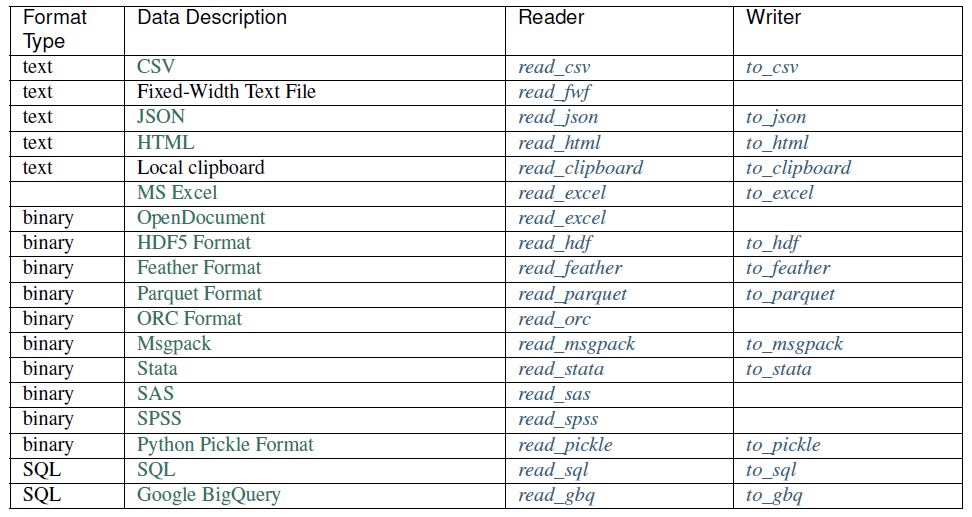

#### ① 写入csv文件

```python
import numpy as np
import pandas as pd
data = np.random.randn(8,3)
dates = pd.date_range('20221001',periods=8)
df = pd.DataFrame(data, index=dates, columns=['A','B','C'])
df
```

|  | A | B | C |
| --- | --- | --- | --- |
| 2022-10-01 | 1.066933 | -2.562281 | -1.362237 |
| 2022-10-02 | 1.053969 | 1.974659 | -1.241883 |
| 2022-10-03 | 0.755891 | -0.898306 | 0.883998 |
| 2022-10-04 | -0.747300 | -0.128126 | -0.237763 |
| 2022-10-05 | -0.359106 | -0.721544 | 0.278124 |
| 2022-10-06 | 1.299013 | -0.563019 | 1.812845 |
| 2022-10-07 | 1.238776 | -0.794907 | 1.470911 |
| 2022-10-08 | 0.339015 | -0.842906 | 1.266611 |

```python
# .to_csv()方法写入csv文件
df.to_csv('sample.csv')  # 在根目录下生成.csv文件，默认将数据导出为逗号分隔的文件
```

```python
df.to_csv('sample.csv',sep='|')  # 更改分隔符
```

```python
import numpy as np
df2=df.copy()
df2.iloc[:3,0]=np.nan  # 将df的部分数据转变为null值
df2.to_csv('sample2.csv')  # 查看该文件，缺失值以空字符串出现
```

```python
import sys
df2.to_csv(sys.stdout,na_rep='NULL')  # 使用NULL对缺失值进行标注
```

```
,A,B,C
2022-10-01,NULL,-2.562280539764033,-1.3622374606529992
2022-10-02,NULL,1.974658838816622,-1.2418830898322646
2022-10-03,NULL,-0.8983061347048817,0.883998072338288
2022-10-04,-0.7472997639556835,-0.12812593161937244,-0.23776348085747703
2022-10-05,-0.35910553515933036,-0.721544144455014,0.2781244654845414
2022-10-06,1.2990134001982938,-0.563019145263454,1.8128448657849525
2022-10-07,1.238775852735482,-0.7949067484181185,1.4709108011869705
2022-10-08,0.3390145029883686,-0.842905678632771,1.2666110737412213
```

```python
df2.to_csv(sys.stdout,na_rep='NULL',index=False,header=False)  # 默认写入行和列标签，也可以禁止写入
```

```
NULL,-2.562280539764033,-1.3622374606529992
NULL,1.974658838816622,-1.2418830898322646
NULL,-0.8983061347048817,0.883998072338288
-0.7472997639556835,-0.12812593161937244,-0.23776348085747703
-0.35910553515933036,-0.721544144455014,0.2781244654845414
1.2990134001982938,-0.563019145263454,1.8128448657849525
1.238775852735482,-0.7949067484181185,1.4709108011869705
0.3390145029883686,-0.842905678632771,1.2666110737412213
```

```python
df2.to_csv(sys.stdout,na_rep='NULL',index=False,columns=['A','C'])  # 只写入列的子集，并按照自定义顺序
```

```
A,C
NULL,-1.3622374606529992
NULL,-1.2418830898322646
NULL,0.883998072338288
-0.7472997639556835,-0.23776348085747703
-0.35910553515933036,0.2781244654845414
1.2990134001982938,1.8128448657849525
1.238775852735482,1.4709108011869705
0.3390145029883686,1.2666110737412213
```

#### ② 读取csv文件

```python
# 使用.read_csv()方法将csv数据文件返回为一个pandas对象
pd.read_csv('sample.csv',sep='|',index_col=0)
```

|  | A | B | C |
| --- | --- | --- | --- |
| 2022-10-01 | 1.066933 | -2.562281 | -1.362237 |
| 2022-10-02 | 1.053969 | 1.974659 | -1.241883 |
| 2022-10-03 | 0.755891 | -0.898306 | 0.883998 |
| 2022-10-04 | -0.747300 | -0.128126 | -0.237763 |
| 2022-10-05 | -0.359106 | -0.721544 | 0.278124 |
| 2022-10-06 | 1.299013 | -0.563019 | 1.812845 |
| 2022-10-07 | 1.238776 | -0.794907 | 1.470911 |
| 2022-10-08 | 0.339015 | -0.842906 | 1.266611 |

```python
pd.read_csv('sample.csv',sep='|',index_col=0,nrows=3)  # 传递nrows参数，只读取部分行
```

|  | A | B | C |
| --- | --- | --- | --- |
| 2022-10-01 | 1.066933 | -2.562281 | -1.362237 |
| 2022-10-02 | 1.053969 | 1.974659 | -1.241883 |
| 2022-10-03 | 0.755891 | -0.898306 | 0.883998 |

```python
pd.read_csv('sample2.csv',index_col=0,na_values='Null')  # na_vallues参数处理缺失值
```

|  | A | B | C |
| --- | --- | --- | --- |
| 2022-10-01 | NaN | -2.562281 | -1.362237 |
| 2022-10-02 | NaN | 1.974659 | -1.241883 |
| 2022-10-03 | NaN | -0.898306 | 0.883998 |
| 2022-10-04 | -0.747300 | -0.128126 | -0.237763 |
| 2022-10-05 | -0.359106 | -0.721544 | 0.278124 |
| 2022-10-06 | 1.299013 | -0.563019 | 1.812845 |
| 2022-10-07 | 1.238776 | -0.794907 | 1.470911 |
| 2022-10-08 | 0.339015 | -0.842906 | 1.266611 |

#### ③ 读取Excel文件

```python
# 使用.read_excel()方法读取Excel文件
# df = pd.read_excel('./超市.xls', sheet_name='订单', index_col='行 ID')  # 相对位置
df = pd.read_excel(r'/Users/yvonne/Jupyter/python-data-analysis/超市.xls', sheet_name='订单', index_col='行 ID')  # 绝对位置
df.head()  # 查看前五行
```

| 行 ID | 订单 ID | 订单日期 | 发货日期 | 邮寄方式 | 客户 ID | 客户名称 | 细分 | 城市 | 省/自治区 | 国家 | 地区 | 产品 ID | 类别 | 子类别 | 产品名称 | 销售额 | 数量 | 折扣 | 利润 |
| --- | --- | --- | --- | --- | --- | --- | --- | --- | --- | --- | --- | --- | --- | --- | --- | --- | --- | --- | --- |
| 1 | US-2018-1357144 | 2018-04-27 | 2018-04-29 | 二级 | 曾惠-14485 | 曾惠 | 公司 | 杭州 | 浙江 | 中国 | 华东 | 办公用-用品-10002717 | 办公用品 | 用品 | Fiskars 剪刀, 蓝色 | 129.696 | 2 | 0.4 | -60.704 |
| 2 | CN-2018-1973789 | 2018-06-15 | 2018-06-19 | 标准级 | 许安-10165 | 许安 | 消费者 | 内江 | 四川 | 中国 | 西南 | 办公用-信封-10004832 | 办公用品 | 信封 | GlobeWeis 搭扣信封, 红色 | 125.440 | 2 | 0.0 | 42.560 |
| 3 | CN-2018-1973789 | 2018-06-15 | 2018-06-19 | 标准级 | 许安-10165 | 许安 | 消费者 | 内江 | 四川 | 中国 | 西南 | 办公用-装订-10001505 | 办公用品 | 装订机 | Cardinal 孔加固材料, 回收 | 31.920 | 2 | 0.4 | 4.200 |
| 4 | US-2018-3017568 | 2018-12-09 | 2018-12-13 | 标准级 | 宋良-17170 | 宋良 | 公司 | 镇江 | 江苏 | 中国 | 华东 | 办公用-用品-10003746 | 办公用品 | 用品 | Kleencut 开信刀, 工业 | 321.216 | 4 | 0.4 | -27.104 |
| 5 | CN-2017-2975416 | 2017-05-31 | 2017-06-02 | 二级 | 万兰-15730 | 万兰 | 消费者 | 汕头 | 广东 | 中国 | 中南 | 办公用-器具-10003452 | 办公用品 | 器具 | KitchenAid 搅拌机, 黑色 | 1375.920 | 3 | 0.0 | 550.200 |